# Estudios de Informática, Multimedia y Telecomunicaciones

## 5.7 Conclusiones

Aunque las conclusiones se han ido comentando a lo largo del ejercicio, en este apartado vamos a tratar de hacer un resumen.

Para realizar este ejercicio hemos creado tres modelo apriori:

- El primero tenía un nivel de soporte de 0.01 y de confianza de 0.5: con esta configuración de parámetros hemos obtenido 50 reglas, las cuales buscaban de reflejar de una forma general el cómo se relacionaban los artistas. Hemos visto que la gran mayoría de las relaciones se producían porque hacían géneros de música similares, eran de la misma zona geográfica, hablaban el mismo idioma o porque escuchaban a grupos famosos.
- El segundo tenía un nivel de soporte de 0.015 y de confianza de 0.5: con esta configuración de parámetros hemos obtenido 9 reglas, las cuales eran más específicas que en el modelo anterior, hemos obtenido las mismas conclusiones que antes con la excepción de que la relaciones entre los artistas ya no estaban influenciadas por los famosos que fueran, es decir, su frecuencia, ya que el parámetro que hemos modifica (soporte) busca eso, considerar que el nivel de frecuencia sea más alto. Un aspecto a tener en cuenta era que a medida que nos poníamos más restrictivos se reducía el valor del lift, lógicamente hay más registros con esos grupos por lo que la aletoriedad va a aumentar ya que hay más casos.
- El tercero tenía un nivel de soporte de 0.015 y de confianza de 0.525: con esta configuración de parámetos hemos obtenido 4 reglas, las cuales eran más restrictivas que en los dos modelos anteriores, las conclusiones encuanto a cómo se relacionaban los artistas eran las mismas que en el modelo anterior. Al igual que sucedía en antes, al aumentar la confianza seguía aumentado la aletoriedad.

# 6 Ejercicio 5

## 6.1 Enunciado

Busca información sobre otros métodos de agregación diferentes al *k-means*. Partiendo del Ejercicio 3, probar el funcionamiento de al menos 2 métodos diferentes y comparar los resultados obtenidos.

## 6.2 Respuesta ejercicio 5

Para realizar este ejercicio hemos decidido usar dos algoritmos de clusterings particionados, el más usado es el kmedias, pero encontramos también el PAM y el CLARA (este último se basa en el PAM pero busca ser eficiente con datasets muy grandes). La principal ventaje de ambos es que no son sensibles a los outliers, mientras que el kmeans sí que lo es.

## 6.3 PAM

Lo primero que debemos hacer es crear el modelo usando PAM, para poder comparar los resultados, vamos a generar el modelo pero vamos a calcular cuál sería el número de clusters ideal para ese modelo, al igual que hicimos con kmeans:

```r
library(factoextra)
```

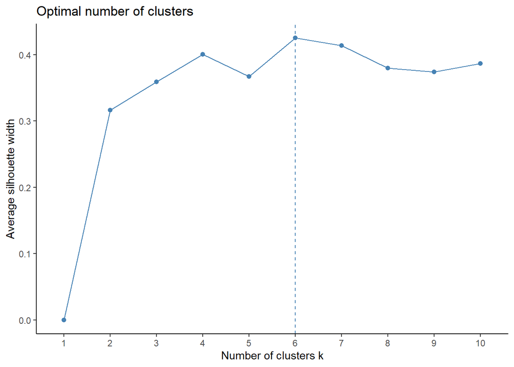

```r
fviz_nbclust(df_clientes_copy, pam, method="silhouette")+theme_classic()
```

Como podemos apreciar en la anterior captura el número de clusters ideales para PAM es de 6, al igual que en el kmeans, por lo tanto generamos el modelo:

```r
set.seed(0)

clientes_pam_k6 = pam(df_clientes_copy, 6)
clientes_pam_k6
```

```
## Medoids:
##       ID        Age      Income Spending_Score
## [1,]  22 -0.9914806 -1.39198127    0.882915982
## [2,]  35  0.7266085 -1.04931630   -1.401822744
## [3,]  81  1.2993049 -0.24976469    0.030979508
## [4,]  98 -0.8483065 -0.02132138   -0.007744877
## [5,] 176 -0.6335454  1.04474743    1.386332990
## [6,] 167  0.2254992  0.96859966   -1.169476433
## Clustering vector:
##   [1] 1 1 2 1 1 1 2 1 2 1 2 1 2 1 2 1 2 1 2 1 2 1 2 1 2 1 2 1 2 1 2 1 2 1 2 1 2
##  [38] 1 2 1 3 1 2 1 2 1 3 4 4 4 3 4 4 3 3 3 3 3 4 3 3 4 3 3 3 4 3 3 4 4 3 3 3 3
##  [75] 3 4 3 4 4 3 3 4 3 3 4 3 3 4 4 3 3 4 3 4 4 4 3 4 3 4 4 3 3 4 3 4 3 3 3 3 3
## [112] 4 4 4 4 4 3 3 3 3 4 4 4 5 4 5 6 5 6 5 6 5 4 5 6 5 6 5 4 5 6 5 4 5 6 5 6 5
## [149] 6 5 6 5 6 5 6 5 6 5 6 5 3 5 6 5 6 5 6 5 6 5 6 5 6 5 6 5 6 5 6 5 6 5 6 5 6
## [186] 5 6 5 6 5 6 5 6 5 6 5 6 5 6 5
## Objective function:
##     build      swap
## 0.8095825 0.7542872
##
## Available components:
##  [1] "medoids"    "id.med"     "clustering" "objective"  "isolation"
##  [6] "clusinfo"   "silinfo"    "diss"       "call"       "data"
```

## 6.4 CLARA

El segundo modelo que vamos a crear es el de CLARA, al igual que antes calculamos el número de clusters ideales para el algoritmo de clara:

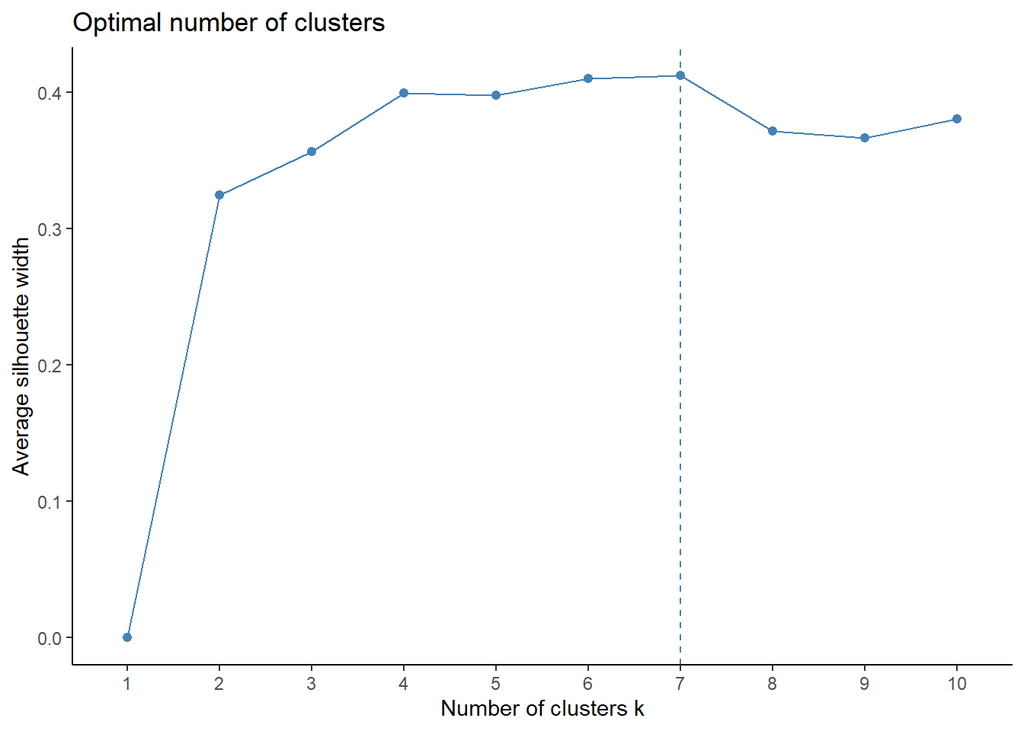

```r
fviz_nbclust(df_clientes_copy, clara, method="silhouette")+theme_classic()
```

En este caso, nos indica que es mejor tener 7 clusters que 6, por lo tanto creamos el modelo con 7 clusters:

```r
set.seed(0)

clientes_clara_k7 = clara(df_clientes_copy, 7)
clientes_clara_k7
```

```
## Call:     clara(x = df_clientes_copy, k = 7)
## Medoids:
##             Age      Income Spending_Score
## [1,] -1.2062418 -0.13554303     0.18587705
## [2,] -1.1346547 -1.20161184     1.42505737
## [3,]  0.4402603 -1.23968573    -0.70478381
## [4,]  2.0151754 -0.51628189     0.06970389
## [5,]  0.5834344 -0.02132138    -0.12391803
## [6,] -0.3471972  0.66400857     1.54123053
## [7,]  0.2254992  0.96859966    -1.16947643
## Objective function:   0.7197142
## Clustering vector:    int [1:200] 1 2 3 2 3 2 3 2 3 2 3 2 3 2 3 2 3 2 ...
## Cluster sizes:            34 21 22 20 32 39 32
## Best sample:
##  [1]   3   7   9  14  18  21  27  30  34  35  36  39  42  44  45  63  64  68  69
## [20]  71  73  79  81  88  91  97 100 104 106 109 110 116 119 120 122 127 128 135
## [39] 140 145 148 150 152 159 165 167 169 170 173 175 179 182 186 196
##
## Available components:
##  [1] "sample"     "medoids"    "i.med"      "clustering" "objective"
##  [6] "clusinfo"   "diss"       "call"       "silinfo"    "data"
```

## 6.5 Comparación de los resultados

Una vez que hemos creado cada modelo según el número de clusters ideales para ese problema, vamos a comparar los resultados que obtenemos a nivel gráfico.

Para ello primero visualizamos las agrupaciones que hace el algoritmo de kmeans respecto a los gastos e ingresos:

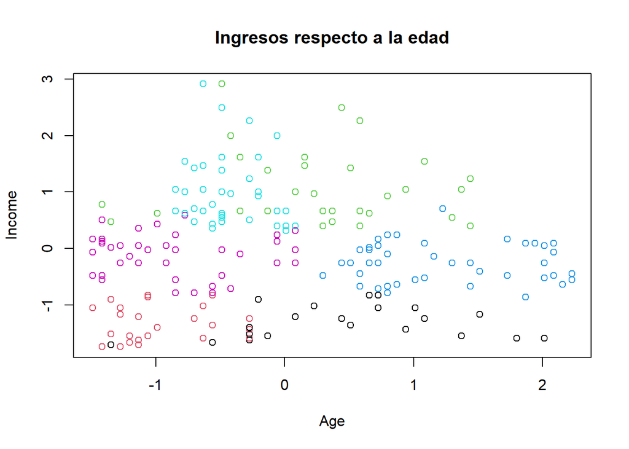

```r
plot(df_clientes_copy[,c(1,2)], col=clientes_kmeans_k6$cluster, main="Ingresos respecto a la edad")
```

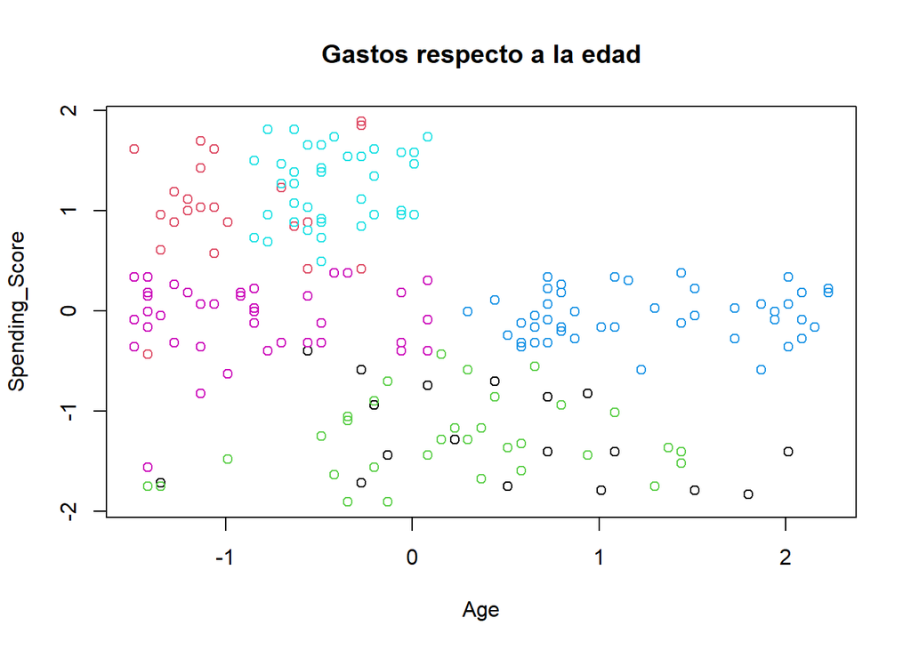

```r
plot(df_clientes_copy[,c(1,3)], col=clientes_kmeans_k6$cluster, main="Gastos respecto a la edad")
```

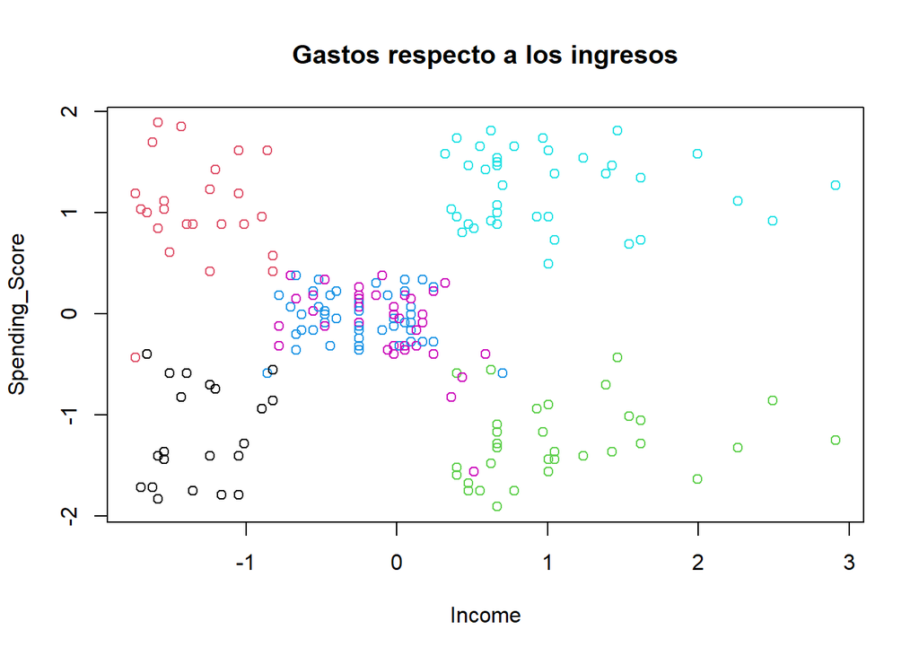

```r
plot(df_clientes_copy[,c(2,3)], col=clientes_kmeans_k6$cluster, main="Gastos respecto a los ingresos")
```

Visualizamos las agrupaciones que hace el algoritmo de PAM respecto a los gastos e ingresos:

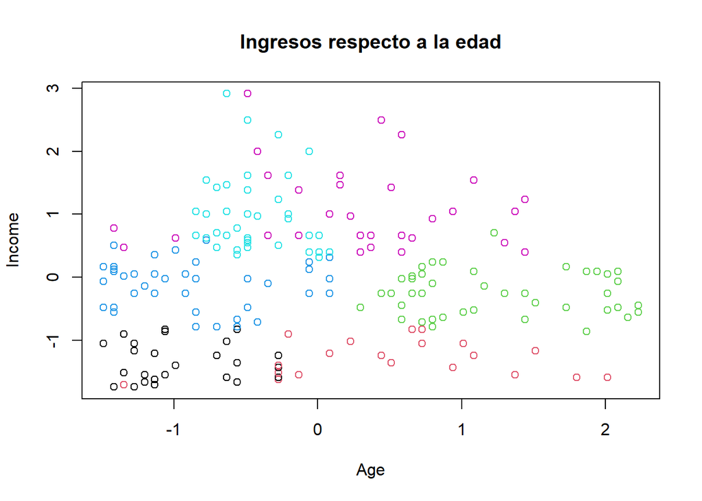

```r
plot(df_clientes_copy[,c(1,2)], col=clientes_pam_k6$clustering, main="Ingresos respecto a la edad")
```

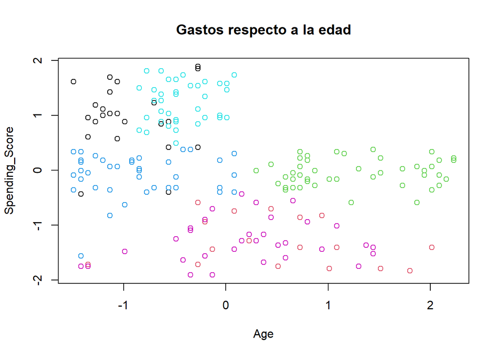

```r
plot(df_clientes_copy[,c(1,3)], col=clientes_pam_k6$clustering, main="Gastos respecto a la edad")
```

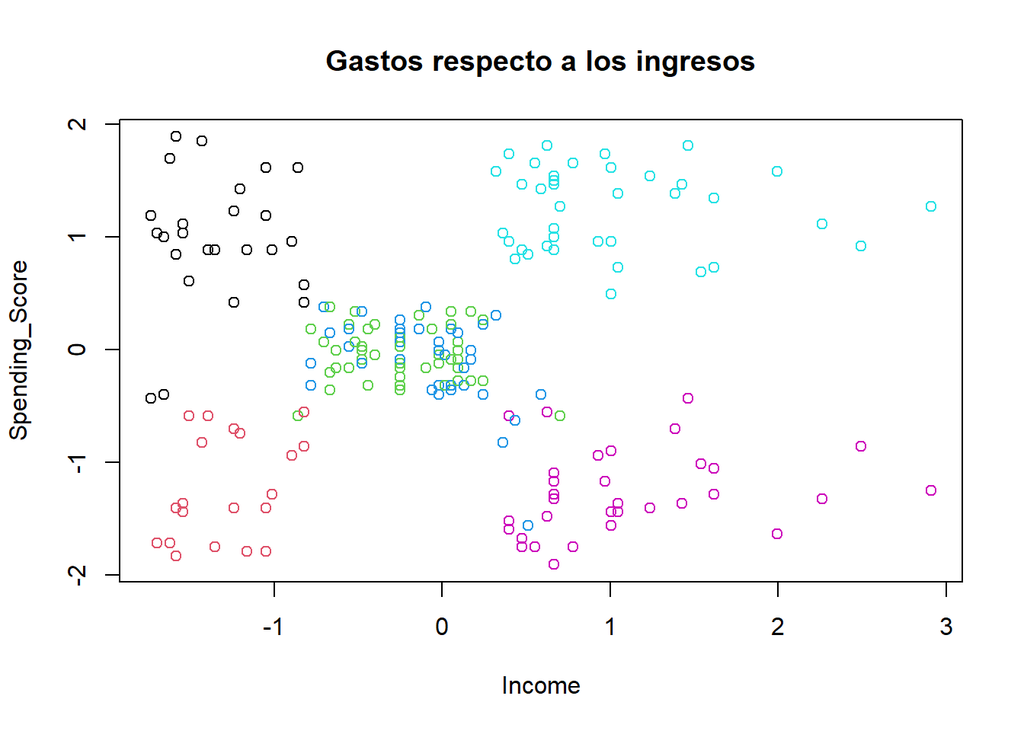

```r
plot(df_clientes_copy[,c(2,3)], col=clientes_pam_k6$clustering, main="Gastos respecto a los ingresos")
```

Visualizamos las agrupaciones que hace el algoritmo de CLARA respecto a los gastos e ingresos:

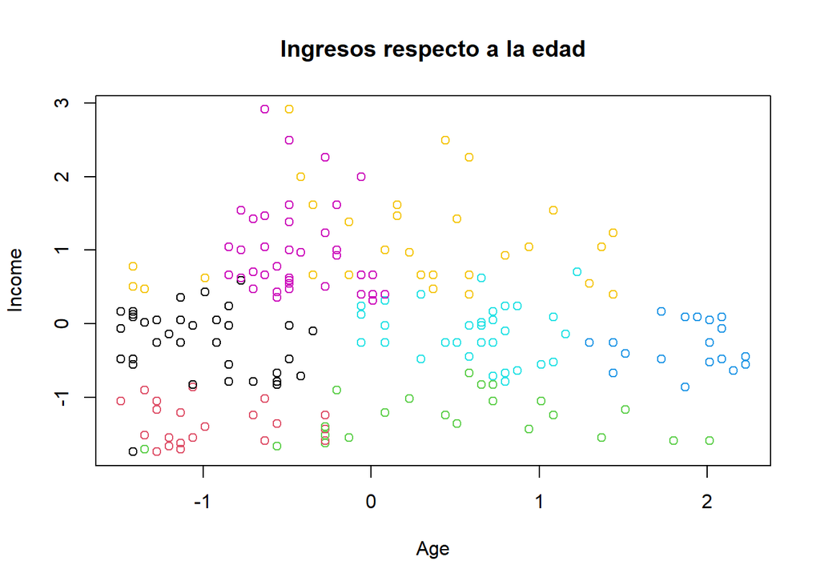

```r
plot(df_clientes_copy[,c(1,2)], col=clientes_clara_k7$clustering, main="Ingresos respecto a la edad")
```

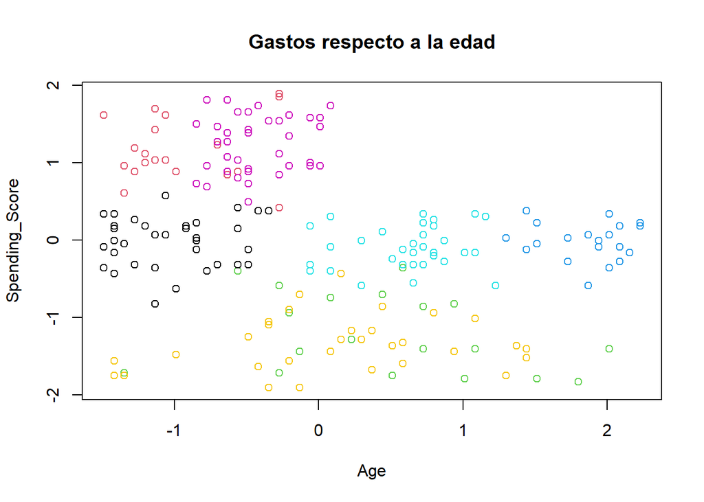

```r
plot(df_clientes_copy[,c(1,3)], col=clientes_clara_k7$clustering, main="Gastos respecto a la edad")
```

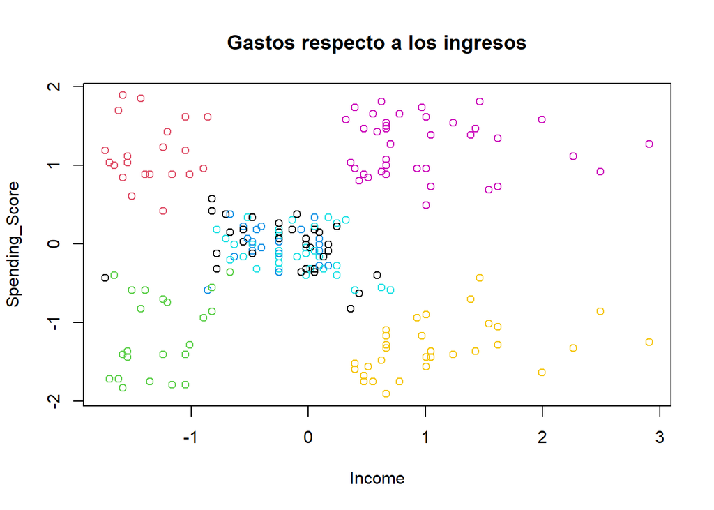

```r
plot(df_clientes_copy[,c(2,3)], col=clientes_clara_k7$clustering, main="Gastos respecto a los ingresos")
```

## 6.6 Conclusiones

Lo primero que cabe destacar es que el dataset no es lo suficientemente grande como para determinar qué algoritmo es mejor, ya que los cambios que hay entre ellos son muy pequeños.

Aún así la ventaja de usar kmeans respecto a los demás, es que es muy fácil de implementar, pero es vulnerable a los outliers, pero si controlamos eso tendremos un buen algoritmo.

Dado el dataset del ejericio 3 entre el kmeans y pam hay muy pocas diferencias, si nos fijamos detenidamente en cada gráfica solo cambia 2 o 3 puntos entre los clusters que define kmeans y pam, sin embargo, esos puntos que cambia desde mi puntos de vista lo hace mejor el algoritmo pam, ya que tienen más sentido porque esos puntos están más cerca de un clúster que de otro. Pero esto no deja de ser relativo, ya que si el dataset es mayor a lo mejor el algoritmo kmeans se comportaba mejor.

# 7 Criterios de evaluación

## 7.1 Ejercicio 1 (20%)

- 60%. Explicar de forma resumida cual es el objetivo de los métodos de agregación. Relacionar la respuesta con un ejemplo.
- 40%. Razonar si tiene sentido aplicar un método agregación al ejemplo que pusiste en la PEC1. Si lo tiene, comentar como se podría aplicar y que tipo de resultados se podrían obtener. Si no lo tiene, reformular el problema para que si lo tenga.

## 7.2 Ejercicio 2 (20%)

- 60%. Explicar de forma resumida cual es el objetivo de los métodos de generación de reglas de asociación. Relacionar la respuesta con un ejemplo.
- 40%. Razonar si tiene sentido aplicar un método de generación de reglas de asociación al ejemplo que pusiste en la PEC1. Si lo tiene, comentar como se podría aplicar y que tipo de resultados se podrían obtener. Si no lo tiene, reformular el problema para que si lo tenga.

## 7.3 Ejercicio 3 (25%)

- 20%. Se explican los campos de la base de datos, preparación y análisis de datos
- 20%. Se aplica el algoritmo de agrupamiento de forma correcta y se prueban con diferentes valores de k.
- 10%. Se obtiene una medida de lo bueno que es el agrupamiento.
- 40%. Se ponen nombres a las asociaciones y se describen e interpretan los diferentes clústers obtenidos.
- 10%. Se presenta el código y es fácilmente reproducible.

## 7.4 Ejercicio 4 (25%)

- 10%. Se realiza un resumen de los datos incluidos en la base de datos.
- 15%. Se preparan los datos de forma correcta.
- 10%. Se aplica el algoritmo de reglas de asociación.
- 20%. Se realizan diferentes pruebas variando algunos parámetros.
- 35%. Se explican las conclusiones que se obtienen.
- 10%. Se presenta el código y es fácilmente reproducible.

## 7.5 Ejercicio 5 (10%)

- 25%. Se prueba un algoritmo diferente al kmeans.
- 25%. Se prueba otro algoritmo diferente al kmeans.
- 40%. Se comparan los resultados del kmeans y los otros dos métodos probados en este ejercicio.
- 10%. Se presenta el código y es fácilmente reproducible.